# Doublet detection for sc-/sn-RNA-Seq Analysis in 10X Genomics data

Antonia Chroni for SJCRH DNB_BINF_Core

DNB Bioinformatics Core Analysis Team:

> **Lead Analyst(s): Antonia Chroni, PhD**  
> Group Lead: Cody A. Ramirez, PhD  
> **Contact E-mail:** user@example.org  
> **DNB Bioinformatics Core Pipeline:** Standard sc-/sn-RNA-Seq Analysis in 10X Genomics data

Reviewed by: _____________________ Date: ____________

# 1 Information about this notebook

This script used the [ScDblFinder](https://bioconductor.org/packages/devel/bioc/vignettes/scDblFinder/inst/doc/scDblFinder.html) method for identifying doublets/multiplets in single-cell data. The scDblFinder method combines the strengths of various doublet detection approaches, training an iterative classifier on the neighborhood of real cells and artificial doublets.

scDblFinder() has two main modes of operation: cluster-based or not. Both perform quite well (see [Germain et al., 2021](https://f1000research.com/articles/10-979)). In general, it is recommended the cluster-based approach in datasets with a very clear cluster structure, and the random approach in more complex datasets.

The input data for scDblFinder can be either i) a count matrix (full or sparse), with genes/features as rows and cells/droplets as columns; or ii) an object of class SingleCellExperiment. In either case, the object should not contain empty drops, but should not otherwise have undergone very stringent filtering (which would bias the estimate of the doublet rate).

# 2 Set up

```r
suppressPackageStartupMessages({
  library(scDblFinder)
  library(Seurat)
  library(scater)
  library(future)
  library(tidyverse)
  library(grid)
  library(knitr)

  # Evaluate Seurat R expressions asynchronously when possible using future package
  options(future.globals.maxSize = future_globals_value)
  plan(multisession, workers = parallelly::availableCores())})
```

# 3 Directories and paths to file Inputs/Outputs

```r
attach(params)
```

```r
analysis_dir <- file.path(root_dir, "analyses", "upstream-analysis")
results_dir <- file.path(analysis_dir, "results")
seurat_results_dir <- file.path(analysis_dir, "results", "02_Seurat_qc")

# Input files
seurat_results_file <- c(dir(path = seurat_results_dir,  pattern = "seurat_obj_raw.rds", full.names = TRUE, recursive = TRUE))
project_metadata_file <- file.path(metadata_dir, metadata_file) # metadata input file

# Create ScDblFinder_results_dir
ScDblFinder_results_dir <- file.path(paste0(results_dir, "/", "03_scDblFinder", "/"))
if (!dir.exists(ScDblFinder_results_dir)) {
  dir.create(ScDblFinder_results_dir)}

# Create to plots directory
plots_dir <- file.path(analysis_dir, "plots")
if (!dir.exists(plots_dir)) {
  dir.create(plots_dir)}

# Create SoupX_plots_dir
scDblFinder_plots_dir <- file.path(plots_dir, paste0("03_scDblFinder"))
if (!dir.exists(scDblFinder_plots_dir)) {
  dir.create(scDblFinder_plots_dir)}

source(paste0(root_dir, "/figures/scripts/theme_plot.R"))
```

# 4 Read metadata file and define `sample_name`

```r
# Read metadata
project.metadata <- read.csv(project_metadata_file, sep = '\t', header = TRUE)
sample_name <- unique(as.character(project.metadata$ID))
sample_name <- sort(sample_name, decreasing = FALSE)
print(sample_name)
```

```
## [1] "DYE_2519" "DYE_2520" "DYE_2521" "DYE_2522"
```

# 5 Read raw seurat_objs

We will load the raw seurat object as generated in the `02A_seurat_alignment_qc.Rmd` step of the pipeline. We will run dimensionality reductions and convert to single cell experiments.

# 6 Run scDblFinder

Next, the `scDblFinder function` is used to identify cells that are doublets based on cluster-based generation of artificial doublets. We will save the cells that need to be filtered based on scDblFinder analysis in a separate table.

```
## [1] "DYE_2519"
## Reading in data for sample DYE_2519
## [[1]]
## An object of class Seurat
## 21763 features across 4865 samples within 1 assay
## Active assay: RNA (21763 features, 0 variable features)
##  2 layers present: counts, data
```

[output not shown]

```
## Beginning to run scDblFinder for sample DYE_2519
```

```
## Clustering cells...
```

```
## 9 clusters
```

```
## Creating ~3892 artificial doublets...
```

```
## Dimensional reduction
```

```
## Evaluating kNN...
```

```
## Training model...
```

```
## iter=0, 330 cells excluded from training.
```

```
## iter=1, 361 cells excluded from training.
```

```
## iter=2, 368 cells excluded from training.
```

```
## Threshold found:0.593
```

```
## 381 (7.8%) doublets called
```

```
##
## singlet doublet
##    4484     381
##  doublet
## 7.831449
## Creating metrics for sample DYE_2519
## Plotting doublets predictions on the UMAP for sample: DYE_2519
## [1] "/sc-rna-seq-snap-legacy-Victoria-Knockout-shareable/analyses/upstream-analysis/plots/03_scDblFinder/DYE_2519_Doublets_prediction.png"
```

```
## [1] "DYE_2520"
## Reading in data for sample DYE_2520
## [[1]]
## class: SingleCellExperiment
## dim: 21763 4865
## metadata(2): scDblFinder.stats scDblFinder.threshold
## assays(2): counts logcounts
## rownames(21763): Xkr4 Gm1992 ... ENSMUSG00000095742 ENSMUSG00000095041
## rowData names(1): scDblFinder.selected
## colnames(4865): DYE_2519:AAACCCAAGCTACAAA DYE_2519:AAACCCAAGCTGTTAC ...
##   DYE_2519:TTTGTTGGTCACTCTC DYE_2519:TTTGTTGTCCTGTAGA
## colData names(24): orig.ident nCount_RNA ...
##   scDblFinder.mostLikelyOrigin scDblFinder.originAmbiguous
## reducedDimNames(2): PCA UMAP
## mainExpName: RNA
## altExpNames(0):
##
## [[2]]
## An object of class Seurat
## 22039 features across 7477 samples within 1 assay
## Active assay: RNA (22039 features, 0 variable features)
##  2 layers present: counts, data
```

[output not shown]

```
## Beginning to run scDblFinder for sample DYE_2520
```

```
## Clustering cells...
```

```
## 9 clusters
```

```
## Creating ~5982 artificial doublets...
```

```
## Dimensional reduction
```

```
## Evaluating kNN...
```

```
## Training model...
```

```
## iter=0, 723 cells excluded from training.
```

```
## iter=1, 715 cells excluded from training.
```

```
## iter=2, 719 cells excluded from training.
```

```
## Threshold found:0.545
```

```
## 740 (9.9%) doublets called
```

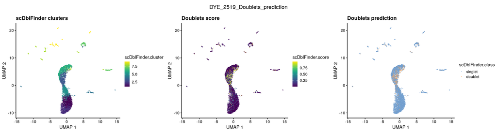

```
##
## singlet doublet
##    6737     740
##  doublet
## 9.897018
## Creating metrics for sample DYE_2520
## Plotting doublets predictions on the UMAP for sample: DYE_2520
## [1] "/sc-rna-seq-snap-legacy-Victoria-Knockout-shareable/analyses/upstream-analysis/plots/03_scDblFinder/DYE_2520_Doublets_prediction.png"
```

```
## [1] "DYE_2521"
## Reading in data for sample DYE_2521
## [[1]]
## class: SingleCellExperiment
## dim: 21763 4865
## metadata(2): scDblFinder.stats scDblFinder.threshold
## assays(2): counts logcounts
## rownames(21763): Xkr4 Gm1992 ... ENSMUSG00000095742 ENSMUSG00000095041
## rowData names(1): scDblFinder.selected
## colnames(4865): DYE_2519:AAACCCAAGCTACAAA DYE_2519:AAACCCAAGCTGTTAC ...
##   DYE_2519:TTTGTTGGTCACTCTC DYE_2519:TTTGTTGTCCTGTAGA
## colData names(24): orig.ident nCount_RNA ...
##   scDblFinder.mostLikelyOrigin scDblFinder.originAmbiguous
## reducedDimNames(2): PCA UMAP
## mainExpName: RNA
## altExpNames(0):
##
## [[2]]
## class: SingleCellExperiment
## dim: 22039 7477
## metadata(2): scDblFinder.stats scDblFinder.threshold
## assays(2): counts logcounts
## rownames(22039): Xkr4 Gm1992 ... ENSMUSG00000095742 ENSMUSG00000095041
## rowData names(1): scDblFinder.selected
## colnames(7477): DYE_2520:AAACCCACACAGAGCA DYE_2520:AAACCCACAGCGAGTA ...
##   DYE_2520:TTTGTTGTCCGAAGGA DYE_2520:TTTGTTGTCTCGCAGG
## colData names(24): orig.ident nCount_RNA ...
##   scDblFinder.mostLikelyOrigin scDblFinder.originAmbiguous
## reducedDimNames(2): PCA UMAP
## mainExpName: RNA
## altExpNames(0):
##
## [[3]]
## An object of class Seurat
## 20190 features across 6351 samples within 1 assay
## Active assay: RNA (20190 features, 0 variable features)
##  2 layers present: counts, data
```

[output not shown]

```
## Beginning to run scDblFinder for sample DYE_2521
```

```
## Clustering cells...
```

```
## 9 clusters
```

```
## Creating ~5081 artificial doublets...
```

```
## Dimensional reduction
```

```
## Evaluating kNN...
```

```
## Training model...
```

```
## iter=0, 547 cells excluded from training.
```

```
## iter=1, 548 cells excluded from training.
```

```
## iter=2, 548 cells excluded from training.
```

```
## Threshold found:0.524
```

```
## 575 (9.1%) doublets called
```

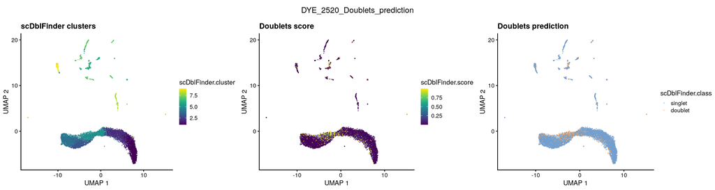

```
##
## singlet doublet
##    5776     575
##  doublet
## 9.053692
## Creating metrics for sample DYE_2521
## Plotting doublets predictions on the UMAP for sample: DYE_2521
## [1] "/sc-rna-seq-snap-legacy-Victoria-Knockout-shareable/analyses/upstream-analysis/plots/03_scDblFinder/DYE_2521_Doublets_prediction.png"
```

```
## [1] "DYE_2522"
## Reading in data for sample DYE_2522
## [[1]]
## class: SingleCellExperiment
## dim: 21763 4865
## metadata(2): scDblFinder.stats scDblFinder.threshold
## assays(2): counts logcounts
## rownames(21763): Xkr4 Gm1992 ... ENSMUSG00000095742 ENSMUSG00000095041
## rowData names(1): scDblFinder.selected
## colnames(4865): DYE_2519:AAACCCAAGCTACAAA DYE_2519:AAACCCAAGCTGTTAC ...
##   DYE_2519:TTTGTTGGTCACTCTC DYE_2519:TTTGTTGTCCTGTAGA
## colData names(24): orig.ident nCount_RNA ...
##   scDblFinder.mostLikelyOrigin scDblFinder.originAmbiguous
## reducedDimNames(2): PCA UMAP
## mainExpName: RNA
## altExpNames(0):
##
## [[2]]
## class: SingleCellExperiment
## dim: 22039 7477
## metadata(2): scDblFinder.stats scDblFinder.threshold
## assays(2): counts logcounts
## rownames(22039): Xkr4 Gm1992 ... ENSMUSG00000095742 ENSMUSG00000095041
## rowData names(1): scDblFinder.selected
## colnames(7477): DYE_2520:AAACCCACACAGAGCA DYE_2520:AAACCCACAGCGAGTA ...
##   DYE_2520:TTTGTTGTCCGAAGGA DYE_2520:TTTGTTGTCTCGCAGG
## colData names(24): orig.ident nCount_RNA ...
##   scDblFinder.mostLikelyOrigin scDblFinder.originAmbiguous
## reducedDimNames(2): PCA UMAP
## mainExpName: RNA
## altExpNames(0):
##
## [[3]]
## class: SingleCellExperiment
## dim: 20190 6351
## metadata(2): scDblFinder.stats scDblFinder.threshold
## assays(2): counts logcounts
## rownames(20190): Xkr4 Gm1992 ... ENSMUSG00000095742 ENSMUSG00000095041
## rowData names(1): scDblFinder.selected
## colnames(6351): DYE_2521:AAACCCAAGAATTCAG DYE_2521:AAACCCAAGCTCCCTT ...
##   DYE_2521:TTTGTTGTCATAGGCT DYE_2521:TTTGTTGTCTCTGAGA
## colData names(24): orig.ident nCount_RNA ...
##   scDblFinder.mostLikelyOrigin scDblFinder.originAmbiguous
## reducedDimNames(2): PCA UMAP
## mainExpName: RNA
## altExpNames(0):
##
## [[4]]
## An object of class Seurat
## 21412 features across 8208 samples within 1 assay
## Active assay: RNA (21412 features, 0 variable features)
##  2 layers present: counts, data
```

[output not shown]

```
## Beginning to run scDblFinder for sample DYE_2522
```

```
## Clustering cells...
```

```
## 10 clusters
```

```
## Creating ~6567 artificial doublets...
```

```
## Dimensional reduction
```

```
## Evaluating kNN...
```

```
## Training model...
```

```
## iter=0, 634 cells excluded from training.
```

```
## iter=1, 736 cells excluded from training.
```

```
## iter=2, 765 cells excluded from training.
```

```
## Threshold found:0.567
```

```
## 866 (10.6%) doublets called
```

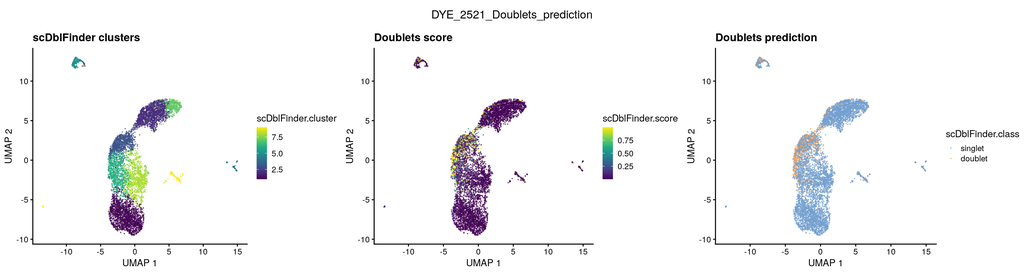

```
##
## singlet doublet
##    7342     866
##  doublet
## 10.55068
## Creating metrics for sample DYE_2522
## Plotting doublets predictions on the UMAP for sample: DYE_2522
## [1] "/sc-rna-seq-snap-legacy-Victoria-Knockout-shareable/analyses/upstream-analysis/plots/03_scDblFinder/DYE_2522_Doublets_prediction.png"
```

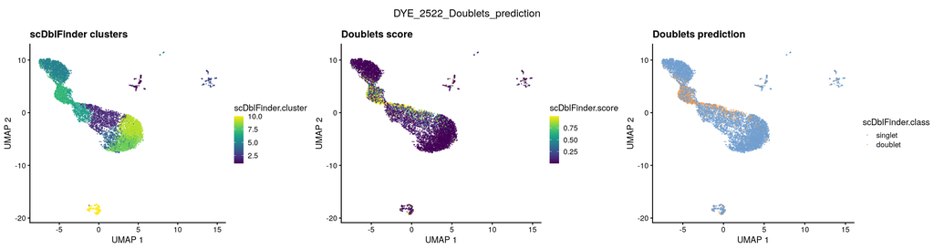

```r
# Create metrics per sample
doublets_metrics <- data.frame(matrix(ncol = 4, nrow = 1))
colnames(doublets_metrics) <- c("sample_name", "singlet", "doublet", "doublets_pct_library") # provide column names

# Create list for seurat and sce
sce_obj_list <- list()
seurat_obj_with_doublets_list <- list()

for (i in seq_along(sample_name)) {
  print(sample_name[i])

  ###############################################################
  cat("Reading in data for sample", sample_name[i], "\n")

  sce_obj_list[i] <- readRDS(seurat_results_file[i])
  print(sce_obj_list)

  set.seed(1234) # Make this reproducible as UMAP algorithm is not deterministic

  # Normalize, find variable features and scale data
  sce_obj_list[[i]] <- sce_obj_list[[i]] %>%
    NormalizeData() %>%
    FindVariableFeatures(selection.method = "vst", nfeatures = 2000) %>%
    ScaleData(verbose = FALSE)

  # Run dim_reductions
  sce_obj_list[[i]] <- RunPCA(sce_obj_list[[i]], features = VariableFeatures(object = sce_obj_list[[i]]), npcs=30) %>%
    RunUMAP(dims = 1:20, n.neighbors=20L, reduction.name = "umap", reduction.key = "UMAP_", verbose = FALSE)

  sce_obj_list[[i]] <- as.SingleCellExperiment(sce_obj_list[[i]])
  ###############################################################
  cat("Beginning to run scDblFinder for sample", sample_name[i], "\n")

  # Run scDblFinder
  bp <- BiocParallel::MulticoreParam(4, RNGseed=1234)
  BiocParallel::bpstart(bp)

  set.seed(1234) # Make this reproducible
  sce_obj_list[[i]] <- scDblFinder(sce_obj_list[[i]], clusters = TRUE, BPPARAM = bp)
  BiocParallel::bpstop(bp)

  # Estimate singlets and doublets in the library
  singlets_doublets_number <- print(table(sce_obj_list[[i]]$scDblFinder.class)) %>%
    as.data.frame() %>%
    mutate(prediction = Var1,
           count = Freq) %>%
    dplyr::select(-Var1, -Freq)

  # Estimate pct of doublets
  doublets_pct_library <- print(table(sce_obj_list[[i]]$scDblFinder.class)[2]/
                                  (table(sce_obj_list[[i]]$scDblFinder.class)[1] +
                                     table(sce_obj_list[[i]]$scDblFinder.class)[2])*100)

  # Format decimal places to keep two digits
  doublets_pct_library <- format(round(doublets_pct_library, 2), nsmall = 2)
  ########################################################################################################
  cat("Creating metrics for sample", sample_name[i], "\n")
  singlet <- as.numeric(singlets_doublets_number %>%
                          dplyr::filter(prediction == "singlet") %>%
                          dplyr::select(-prediction) %>%
                          dplyr::mutate(singlet = count) %>%
                          dplyr::select(-count))

  doublet <- as.numeric(singlets_doublets_number %>%
                          dplyr::filter(prediction == "doublet") %>%
                          dplyr::select(-prediction) %>%
                          dplyr::mutate(doublet = count) %>%
                          dplyr::select(-count))

  doublets_metrics[i,] <- c(sample_name[i], singlet, doublet, doublets_pct_library)
  ########################################################################################################
  doublets <- sce_obj_list[[i]]@colData[,str_detect(colnames(sce_obj_list[[i]]@colData),"scDblFinder")] %>%
    as.data.frame() %>%
    tibble::rownames_to_column("cell")

  # Cells that we need to filter from the final object
  doublets_to_filter <- subset(doublets, doublets$scDblFinder.class == "doublet")

  # Convert sce list into seurat list
  seurat_obj_with_doublets_list[[i]] <- as.Seurat(sce_obj_list[[i]],
                                        counts = "counts", # includes spliced and unspliced transcripts
                                        data = "logcounts") # derived from the counts matrixs

  ########################################################################################################
  # Plot the Doublets predictions on the UMAP
  cat("Plotting doublets predictions on the UMAP for sample:", sample_name[i], "\n")
  # merge all three plots within one grid (and visualize this)
  fname_png <- paste0(scDblFinder_plots_dir, "/", sample_name[i], "_Doublets_prediction.png")
  print(fname_png)
  gridExtra::grid.arrange(plot1 <- plotUMAP(sce_obj_list[[i]], colour_by = "scDblFinder.cluster", point_size = 0.1) + ggtitle("scDblFinder clusters"),
                          plot2 <- plotUMAP(sce_obj_list[[i]], colour_by = "scDblFinder.score", point_size = 0.1) + ggtitle("Doublets score"),
                          plot3 <- plotUMAP(sce_obj_list[[i]], colour_by = "scDblFinder.class", point_size = 0.1) + ggtitle("Doublets prediction"),
                          ncol = 3, nrow = 1, top = paste0(sample_name[i], "_Doublets_prediction"), padding = unit(1.5, "line"))

  g <- gridExtra::arrangeGrob(plot1, plot2, plot3, ncol = 3, nrow = 1,
                              top = paste0(sample_name[i], "_Doublets_prediction"),
                              padding = unit(1.5, "line")) #generates g
  ggsave(file = fname_png, g, width = 15, height = 4, device = "png")
  #######################################################################################
  # Save results for all libraries for cells to be filtered out
  if(i == 1){
    doublets_to_filter_all <- doublets_to_filter
    } else {
      doublets_to_filter_all <- rbind(doublets_to_filter_all, doublets_to_filter)}
  }
```

```r
# Save table with doublets_metrics
write_tsv(doublets_metrics, paste0(ScDblFinder_results_dir, "/", "doublets_metrics.tsv"))
```

# 7 Doublets detection per sample

We will summarize the estimated and removed doublets per sample.

Summary of doublets detection per sample

| sample_name | singlet | doublet | doublets_pct_library |
| --- | --- | --- | --- |
| DYE_2519 | 4484 | 381 | 7.83 |
| DYE_2520 | 6737 | 740 | 9.90 |
| DYE_2521 | 5776 | 575 | 9.05 |
| DYE_2522 | 7342 | 866 | 10.55 |

# 8 Create seurat object with all samples

We will create seurat objects and merge them into one. This will be used for filtering out the doublets.

```r
# Merge all seurat objects in the list into one
# The first parameter of merge should be a Seurat object, the second (y) can be one Seurat object or a list of several.
merged_seurat_obj <- merge(x = seurat_obj_with_doublets_list[[1]], y = seurat_obj_with_doublets_list[-1],
                           project = PROJECT_NAME)

# Remove any columns with NAs
merged_seurat_obj@meta.data <- merged_seurat_obj@meta.data %>%
  select_if(~ !any(is.na(.)))
print(DefaultAssay(merged_seurat_obj) <- "RNA") # Switch the default to RNA
```

```
## [1] "RNA"
```

```r
# Add metadata
cat("Adding metadata to merged_seurat_obj\n")
```

```
## Adding metadata to merged_seurat_obj
```

```r
sample.metadata <- rbind(project.metadata[i, ], project.metadata[i, ][rep(1, length(merged_seurat_obj$nCount_RNA)-1), ])
merged_seurat_obj@meta.data <- cbind(merged_seurat_obj@meta.data, sample.metadata)

# Cells_number_before_filter per sample_id
print(table(merged_seurat_obj@meta.data$orig.ident))
```

```
##
## DYE_2519 DYE_2520 DYE_2521 DYE_2522
##     4865     7477     6351     8208
```

```r
saveRDS(merged_seurat_obj, file = paste0(ScDblFinder_results_dir, "/", "merged_seurat_obj_with_doublets.rds")) # save object
```

```r
# Number of singlet vs doublet in seurat object
#print(table(merged_seurat_obj@meta.data$scDblFinder.class))

#split_obj <- SplitObject(merged_seurat_obj, split.by = "scDblFinder.class") # Split object based on scDblFinder prediction
#filter_obj <- subset(split_obj$singlet) # Keep cells with singlet
#Idents(filter_obj) <- "orig.ident" # Set cell identity classes

# Cells_number_after_filter per `sample_name`
#print(table(filter_obj@meta.data$orig.ident))

#saveRDS(filter_obj, file = paste0(ScDblFinder_results_dir, "/", "merged_seurat_obj_without_doublets.rds")) # save object
```

# 9 Next steps

We have identified doublets from the libraries.